# Lab 2 Writeup

Cecilia Millane

2/1/2018

1. Cecilia Millane Ruben Arias Nick Freelove Liuyi Bao
2. https://github.com/c-millane/Lab2

# Team Work

```r
choco <- read.csv("https://ds202-at-isu.github.io/labs/data/choco.csv")
head(choco)
```

```
##    Company Specific.Bean.Origin  REF Review.Date Cocoa.Pct
## 1 A. Morin          Agua Grande 1876        2016        63
## 2 A. Morin                Kpime 1676        2015        70
## 3 A. Morin               Panama 1011        2013        70
## 4 A. Morin           Madagascar 1011        2013        70
## 5 A. Morin               Brazil 1011        2013        70
## 6 A. Morin             Equateur 1011        2013        70
##   Company.Location Rating Bean.Type Broad.Bean.Origin
## 1           France   3.75                    Sao Tome
## 2           France   2.75                        Togo
## 3           France   2.75                      Panama
## 4           France   3.00   Criollo        Madagascar
## 5           France   3.25                      Brazil
## 6           France   3.75                     Ecuador
```

```r
names(choco)
```

```
## [1] "Company"              "Specific.Bean.Origin" "REF"
## [4] "Review.Date"          "Cocoa.Pct"            "Company.Location"
## [7] "Rating"               "Bean.Type"            "Broad.Bean.Origin"
```

```r
dim(choco)
```

```
## [1] 1852    9
```

```r
library(ggplot2)
```

There are 1,852 rows of data.

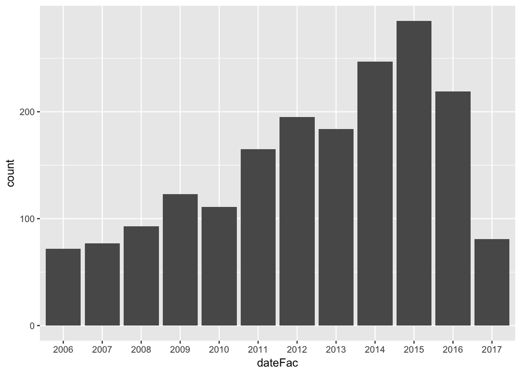

```r
dateFac <- as.factor(choco$Review.Date)
ggplot(data= choco, aes(x= dateFac)) + geom_bar()
```

The number of ratings was gradually increasing, but in the past couple years, the number has significantly dropped.

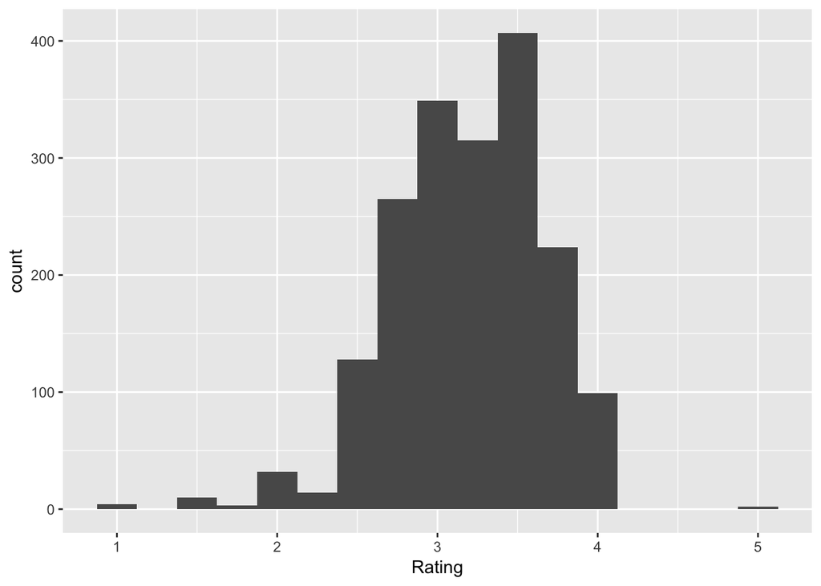

```r
ggplot(data= choco, aes(x= Rating)) + geom_histogram(binwidth=0.25)
```

This histogram is unimodel and appears to be fairly symmetric in shape besides a slight skew to the left, with more data falling below the mode than above it. There also appears to be an outlier at a rating of 5.

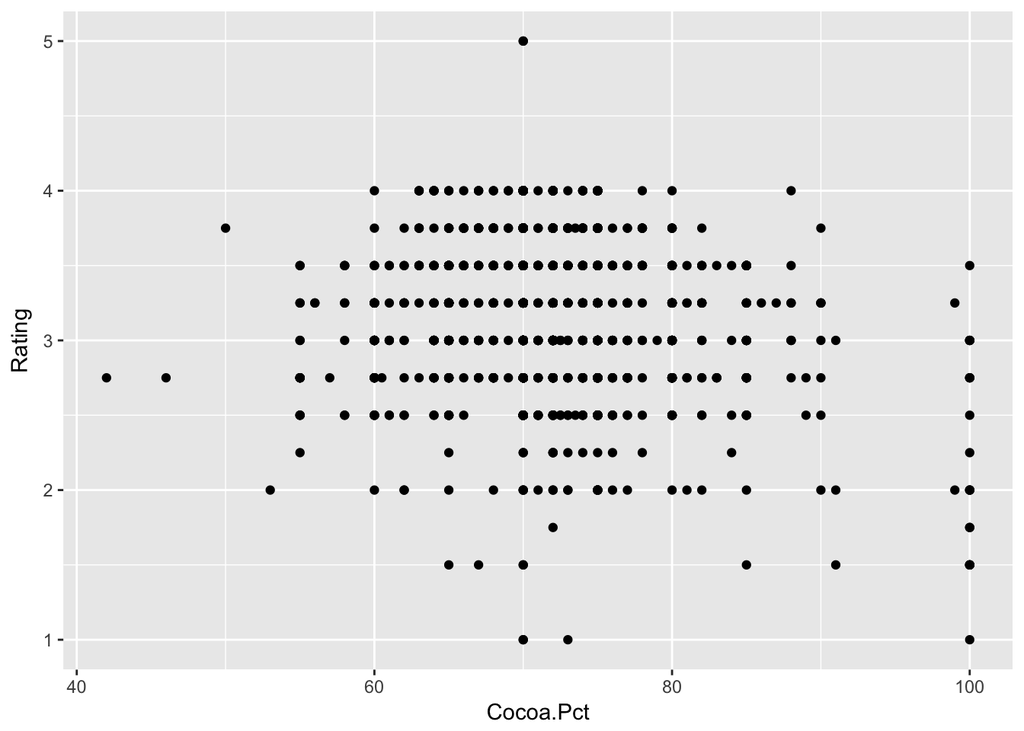

```r
ggplot(data= choco, aes(x= Cocoa.Pct, y= Rating, group = Cocoa.Pct)) + geom_point()
```

No the rating does not depend on the Cocoa percentage because this scatter plot shows that the cocoa percentages of the candy bars are given all types of ratings. For example, chocoalte bars with a cocoa percentage of 100% have ratings ranging between 1 and approximately 3.5. The medians for all of the percentages fall around the same place.

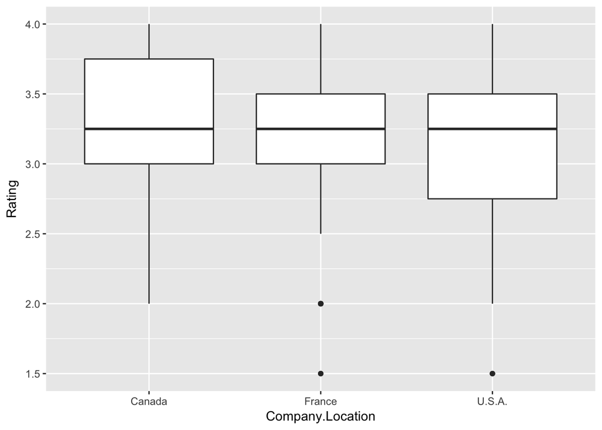

```r
p3 <- dplyr::filter(choco, Company.Location %in% c("U.S.A.", "France", "Canada"))
ggplot(data= p3, aes(x= Company.Location, y= Rating)) + geom_boxplot()
```